# RcppMsgPack: MessagePack Headers and Interface Functions for R

MessagePack, or *MsgPack* for short, or when referring to the implementation, is an efficient binary serialization format for exchanging data between different programming languages. The *RcppMsgPack* package provides *R* with both the MessagePack *C++* header files, and the ability to access, create and alter MessagePack objects directly from *R*. The main driver functions of the R interface are two functions `msgpack_pack` and `msgpack_unpack`. The function `msgpack_pack` serializes *R* objects to a raw MessagePack message. The function `msgpack_unpack` de-serializes MessagePack messages back into *R* objects. Several helper functions are available to aid in processing and formatting data including `msgpack_simplify`, `msgpack_format` and `msgpack_map`.

Travers Ching (Unaffiliated) , Dirk Eddelbuettel (Department of Statistics, University of Illinois at Urbana-Champaign)  
2018-12-08

### 1 Introduction

MessagePack (or *MsgPack* for short, or when referring to the actual implementation) is a binary serialization format made for exchanging data between different programming languages (Furuhashi 2018). Unlike other related formats such as JSON, *MsgPack* is a binary format—which makes it more efficient in terms of (disk or memory) space, transfer speeds (which is increasingly important for large data sets across networks) and potentially also precision (as textual representation rarely goes to the length of binary precision). As shown on the project homepage at https://msgpack.org, several major projects including *Redis*, *Pinterest*, *Fluentd* and *Treasure Data* utilize *MsgPack* to transfer data or to represent internal data structures (Furuhashi 2018). Other binary serialization formats similar to *MsgPack* include BSON (MongoDB 2018) and ProtoBuf (Google 2018) which have their own advantages and disadvantages, such as serialization speed, memory usage, compression and requirement of descriptive schemas (Dawborn and Curran 2014; Hamida et al. 2015). *R* support for these formats is available via the packages [*mongolite*](https://CRAN.R-project.org/package=mongolite) (Ooms 2014) and [*RProtoBuf*](https://CRAN.R-project.org/package=RProtoBuf) (Eddelbuettel et al. 2016); Redis is also implemented in *R* through the [*RcppRedis*](https://CRAN.R-project.org/package=RcppRedis) package (Eddelbuettel 2018). [*RcppMsgPack*](https://CRAN.R-project.org/package=RcppMsgPack) (Ching et al. 2018) brings support for the *MsgPack* specification to *R*.

The *MsgPack* specification describes a number of common data type: Booleans, Integers, Floats, Strings, Binary data, Arrays, Maps, and user-defined extension types, and has been implemented in most major programming languages. *RcppMsgPack* aims to provide an efficient, and easy to use implementation by relying on the official *C++* *MsgPack* code and the [*Rcpp*](https://CRAN.R-project.org/package=Rcpp) package (Eddelbuettel 2013; Eddelbuettel et al. 2018). The package provides users with the *MsgPack* header files which can be used to more directly integrate *MsgPack* into *R* projects through *C++* code. It also provides the ability to serialize and de-serialize data directly to and from *R* (*e.g.*, through pipes, file handlers, sockets or binary object files). These functionalities can be used to efficiently transfer data between various programming languages and between separate *R* instances.

In this manuscript, we describe the main interface functions used to serialize and deserialize *MsgPack* messages, and the conversion between *R* data types and *MsgPack* data types. We describe helper functions contained in *RcppMsgPack* and describe several use cases and examples of how *RcppMsgPack* can be used in practice, benchmarking several common approaches for transferring data between processes.

### 2 Interface functions

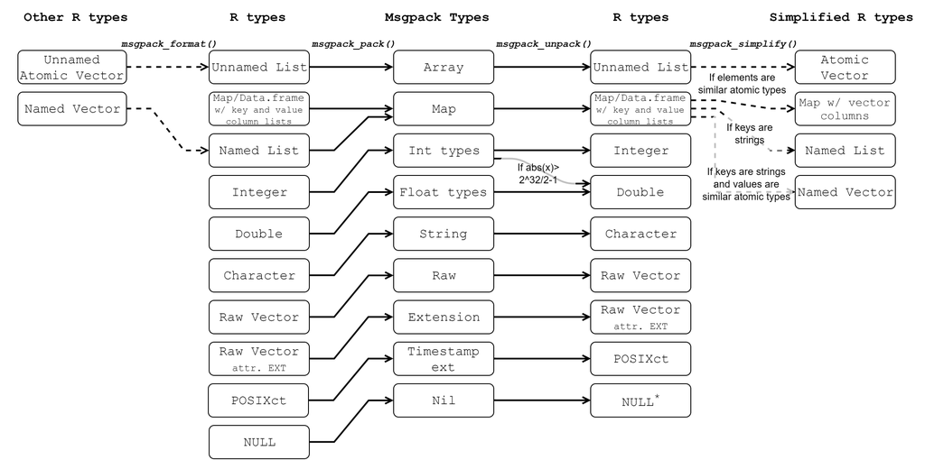

Figure 1: A flowchart of the conversion of *R* objects to *MsgPack* objects and vice versa.

The functions `msgpack_pack` and `msgpack_unpack` allow serialization and de-serialization of *R* objects respectively (Figure 1). Here, `msgpack_pack` takes in any number of *R* objects and generates a single serialized message in the form of a raw vector. Conversely, `msgpack_unpack` takes a serialized message as input, and returns the *R* object(s) contained in the message. Moreover, `msgpack_format` is a helper function to properly format *R* objects for input, and `msgpack_simplify` is a helper function to simplify output from a *MsgPack* conversion. One of the main goals of *MsgPack* is the transfer of data across processes and/or hosts. Therefore, we also define two helper functions `msgpack_write` and `msgpack_read` which facilitate writing and reading of *MsgPack* objects to files, pipes or any connection object.

The data types in *MsgPack* do not directly map on to *R* data types, more so than other languages. For example, basic *R* “atomic” types such as integers and strings are inherently vectorized, which is not true in *C++*, Python or most other languages. *I.e.*, in *R* there is no distinction between a single integer and a vector of integers of length 1. *R* also has multiple non-value types, such as `NULL` or `NA` for integer, string, numeric, etc. Because of these complexities, the conversion processes using these interface functions are described in detail below.

*R* integers are converted into *MsgPack* integers, which are automatically reduced in size, depending on the value of the integer. *MsgPack* integers are converted back into *R* integers. Because *R* does not natively support 64 bit integers, whereas *MsgPack* supports integers up to 64 unsigned bits in value, *MsgPack* integers exceeding signed 32 bits supported by *R* are coerced to *R* numeric values, with potential loss of precision. The integer `NA` value in *R* is represented by its bit value in *C++* (0x80000000), and requires no special treatment.

*R* `numeric` (*i.e.*, doubles) variables conform to IEEE 754 double-precision standards (IEEE Standards Committee 2008), and also require no special treatment. The numeric NA value is a special case of NaN values, and is serialized by its bit representation.

*R* strings (*i.e.*, objects of class `character`) are converted to *MsgPack* strings. Because *C++* and *MsgPack* do not have missing values for strings, NA characters are converted into *MsgPack* Nil (similar to `NULL` in *R*).

*R* `logical` values are converted into *MsgPack* bool. Again, because NA logical values do not exist in *C++* or *MsgPack*, NA logical values are converted into *MsgPack* Nil.

*R* `raw` vectors are converted into *MsgPack* bin. Raw vectors with the “EXT” integer attribute are converted into *MsgPack* extension types. The EXT attribute should be a positive integer, as negative values are reserved for official extensions.

Currently, the *MsgPack* specifications includes one official extension type: timestamps. Timestamps are a *MsgPack* extension type with extension value -1 and can be converted to and from *R* `POSIXct` objects using `msgpack_timestamp_decode` and `msgpack_timestamp_encode` respectively. *MsgPack* timestamps can encode nanosecond precision. *R* `POSIXct` objects rely on `numeric`, and therefore conversion may have some loss of precision (unless a package such as [*nanotime*](https://CRAN.R-project.org/package=nanotime) (Eddelbuettel and Silvestri 2018) is used, which is left as a future extension).

*MsgPack* specifications define two container objects: arrays and maps. *MsgPack* arrays are a sequential container object. The length of the array is defined in its message header. Arrays can contain any other *MsgPack* types, including other arrays or maps.

*MsgPack* arrays are naturally analogous to *R* `unnamed list` objects. However, because lists have a large memory footprint, *R* atomic vectors (with length of 0 or greater than or equal to 2) are also allowed as input for serialization to arrays.

*MsgPack* maps are an ordered sequence of key and value pairs, where each key and value can be any *MsgPack* object. There is no requirement for unique keys. Maps do not have an analogous data type in *R* . Therefore, maps are implemented by creating an object of class `map`, which is also a `data.frame` with `key` and `value` columns. As input to serialization, these columns can also be lists, and can therefore contain any other *R* object, and not only a single type. The function `msgpack_map` is a simple helper function that takes two lists and returns a `map` which can be serialized into a *MsgPack* object with `msgpack_pack`.

In order to support as much generality as possible in serialization and deserialization, the use of lists to represent arrays and maps is necessary. However, it is often the case in *R* that one would want to deal with large vectors or matrices of a single type without the computational and memory overhead of lists. Two approaches are given to deal with this type of scenario. `msgpack_simplify` can be used after a call to `msgpack_unpack` to recursively simplify lists to vectors when only a single type is included within a list. (For lists of characters or logicals, this may also include NULLs.) Secondly, `msgpack_unpack` can be called with the `simplify=TRUE` parameter, which performs the same task as `msgpack_simplify` within *C++*, and is therefore much faster. The second approach can drastically improve speed and memory usage compared to the first approach.